# Solving problems using nonparametric methods in R

Eduardo Marquez Mora

2025

## 1. Quality Control (Runs Test for Randomness)

A quality-control inspector tracks the compressive strength of parts created by an injection molding process. If the process is in control, the strengths should fluctuate randomly around the target value of 75 psi. The inspector measures the strength of 20 parts as they come off the production line and obtains the following strengths, in order:

```r
# Strengths of 20 parts
strengths = c(82.0,78.3,73.5,74.4,72.6,79.8,77.0,83.4,76.2,75.2,81.5,69.8,71.3,69.4,82.1,77.6,76.9,77.1,72.7,73.6)
nStrengths = length(strengths)

print(strengths)
```

```
##  [1] 82.0 78.3 73.5 74.4 72.6 79.8 77.0 83.4 76.2 75.2 81.5 69.8 71.3 69.4 82.1
## [16] 77.6 76.9 77.1 72.7 73.6
```

### Conducting a Runs Test for Randomness of the compression strengths at the α = 0.05 level of significance

```r
# Perform runs test

runs.test(strengths, threshold = 75, alternative = "two.sided")
```

```
##
##  Runs Test
##
## data:  strengths
## statistic = -2.2067, runs = 6, n1 = 12, n2 = 8, n = 20, p-value =
## 0.02733
## alternative hypothesis: nonrandomness
```

Since p-value = 0.02733 < 0.05, we **reject Ho**.  
There is enough evidence at the 0.05 level to claim that the sequence of parts’ strengths is nonrandom.

## 2. Acid Rain Problem

In 2002, the median pH level of the rain in Glacier National Park, Montana, was 5.25. A biologist thinks that the acidity of rain has decreased since then, which would suggest the pH has increased. The biologist obtains a random sample of 15 rain dates in 2022 and records the following data:

```r
# Data

rainData = c(5.31, 5.19, 5.55, 5.38, 5.37, 5.19, 5.26, 5.29, 5.27, 5.19, 5.27, 5.36, 5.22, 5.28, 5.24)

print(rainData)
```

```
##  [1] 5.31 5.19 5.55 5.38 5.37 5.19 5.26 5.29 5.27 5.19 5.27 5.36 5.22 5.28 5.24
```

### Using the **sign test**, we can determine whether there is significant evidence at the α = 0.05 level to conclude that the median pH level in 2022 is greater than 5.25.

```r
# Calculate differences

differences = rainData - 5.25

# Remove values equal to 5.25 (avoid ties)

differencesNoTies = differences[differences != 0]

sampleSizeDifferences = length(differencesNoTies)

# Count number of positive signs (above 5.25)

positiveSigns = sum(differencesNoTies > 0)

# Perform the exact binomial test

binom.test(positiveSigns, sampleSizeDifferences, p = 0.5, alternative = "greater")
```

```
##
##  Exact binomial test
##
## data:  positiveSigns and sampleSizeDifferences
## number of successes = 10, number of trials = 15, p-value = 0.1509
## alternative hypothesis: true probability of success is greater than 0.5
## 95 percent confidence interval:
##  0.4225563 1.0000000
## sample estimates:
## probability of success
##              0.6666667
```

### Hypothesis test and interpreting results

H0 : η = 5.25  
Ha : η > 5.25 (right–tailed)

Since p-value = 0.1509 > 0.05, we **fail to reject Ho**.

At 0.05 level, we don’t have enough evidence to claim that the median pH level in 2022 is greater than 5.25

## 3. Effect of Aspirin on Blood Clotting

Blood clotting is due to a sequence of chemical reactions. The protein thrombin initiates blood clotting by working with another protein, **prothrombin**. It is common to measure an individual’s blood clotting time as prothrombin time, the time between the start of the thrombin–prothrombin reaction and the formation of the clot. Researchers wanted to study the effect of aspirin on prothrombin time. They randomly selected 12 subjects and measured the prothrombin time (in seconds) without taking aspirin and again 3 hours after taking two aspirin tablets. To solve, we will use the **Wilcoxon Signed-Rank test** for paired samples with the following data:

```r
# Data

beforeAspirin = c(12.3, 12.0, 12.0, 13.0, 13.0, 12.5, 11.3, 11.8, 11.5, 11.0, 11.0, 11.3)

afterAspirin = c(12.0, 12.3, 12.5, 12.0, 13.0, 12.5, 10.3, 11.3, 11.5, 11.5, 11.0, 11.5)

# Perform Wilcoxon Signed-Rank test (paired)

wilcox.test(beforeAspirin,afterAspirin,
            paired = TRUE,
            alternative = "two.sided",
            exact = FALSE,
            correct = FALSE)
```

```
##
##  Wilcoxon signed rank test
##
## data:  beforeAspirin and afterAspirin
## V = 22.5, p-value = 0.5256
## alternative hypothesis: true location shift is not equal to 0
```

### Hypothesis test and interpreting results

Ho = Md = 0  
Ha = Md != 0

Since p-value = 0.5256 > 0.05 (alpha), we **fail to reject Ho**.

At 0.05 level, there is not enough evidence to claim that the aspirin affects the median prothrombin time.

## 4. Calcium in Rainwater (Independent Samples)

Calcium in Rainwater. An environmentalist wants to determine whether the median calcium level (mg/L) in rainwater from Lincoln County, Nebraska, differs from that in Clarendon County, South Carolina. During weeks when rain occurred, calcium levels were recorded for n1 = 22 weeks in Lincoln County and n2 = 20 weeks in Clarendon County. To test whether the two population medians differ, we must use the **Mann Whitney U Test**

```r
# Data

lincolnCounty = c(0.11, 0.41, 0.19, 0.33, 0.09, 0.33, 0.67, 0.20, 0.21, 0.20, 0.75, 0.42, 0.09, 0.22, 0.19, 0.25, 0.07, 0.34, 0.30, 0.47, 0.30, 0.46)

clarendonCounty = c(0.06, 0.12, 0.14, 0.10, 0.09, 0.29, 0.14, 0.21, 0.14, 0.10, 0.12, 0.16, 0.16, 0.41, 0.08, 0.13, 0.03, 0.08, 0.09, 0.12)

lincolnLength = length(lincolnCounty); lincolnLength
```

```
## [1] 22
```

```r
clarendonLength = length(clarendonCounty); clarendonLength
```

```
## [1] 20
```

```r
# Mann Whitney (Wilcoxon rank-sum) test: two tailed

wilcox.test(lincolnCounty, clarendonCounty,
            alternative = "two.sided",
            exact = FALSE,
            correct = FALSE)
```

```
##
##  Wilcoxon rank sum test
##
## data:  lincolnCounty and clarendonCounty
## W = 356, p-value = 0.0006062
## alternative hypothesis: true location shift is not equal to 0
```

### Hypothesis test and interpreting results

Ho = M1 = M2  
Ha = M1 != M2

Since p-value = 0.0006062 < 0.05 (alpha), we **reject Ho**.

There is enough evidence at the 0.05 level to claim that the two population medians differ.

## 5. Does Defense Win?

Does Defense Win? “Defense wins championships” is a common phrase used in the National Football League. Is defense associated with winning? To assess this, we can use the **Spearman’s rank test**. The following data represents the winning percentage and the yards per game allowed during the 2022–2023 season for a random sample of teams:

```r
# Data

winningPercentage = c(0.588, 0.412, 0.294, 0.529, 0.471, 0.353, 0.529)

yardsPerGameAllowed = c(324.3, 331.2, 320.0, 353.3, 322.0, 365.6, 330.4)

# Spearman's rank test

spearman_out = cor.test(winningPercentage, yardsPerGameAllowed,
                        method = "spearman",
                        exact = FALSE,
                        alternative = "less")

spearman_out$estimate
```

```
##      rho
## 0.072075
```

```r
# p-value

spearman_out$p.value
```

```
## [1] 0.5610204
```

### Hypothesis test and interpreting results

Ho = ρs = 0  
Ha = ρs < 0

Since p-value = 0.5610204 > 0.10 (alpha), we **fail to reject Ho**.

At 0.10 level, there is not enough evidence to claim that higher winning percentages are associated with fewer yards allowed.

## Scatter Plot to showcase relationship between yards per game allowed and winning percentage

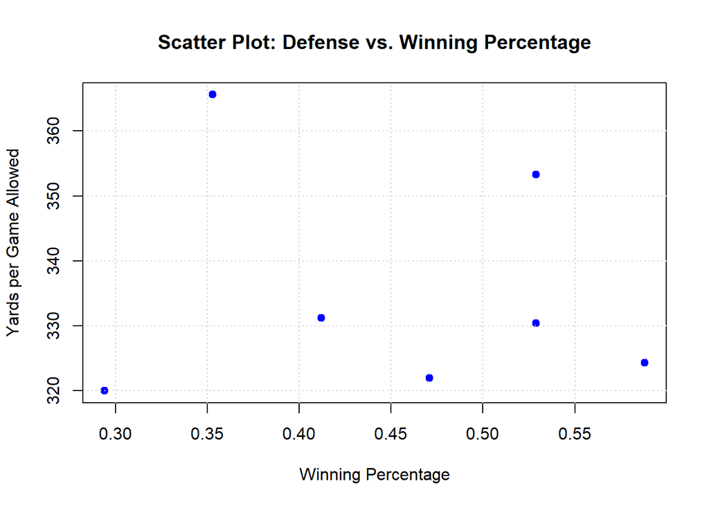

```r
# --- Scatterplot for visual relationship ---
plot(winningPercentage, yardsPerGameAllowed,
pch = 19, col = "blue",
xlab = "Winning Percentage",
ylab = "Yards per Game Allowed",
main = "Scatter Plot: Defense vs. Winning Percentage")
grid()
```

## 6. Comparing Math exams scores from different countries

Researchers wanted to compare math test scores of students at the end of secondary school from various countries. Eight randomly selected students from Canada, Denmark, and the United States each were administered the same exam; the results are presented below. Using the **Kruskal-Wallis Test** we can test whether the distributions (medians) of exam scores are the same across the three countries:

```r
# Data

canadaScores = c(578, 548, 548, 530, 521, 502, 555, 492)

denmarkScores = c(568, 563, 530, 535, 571, 561, 569, 513)

usaScores = c(506, 458, 518, 456, 485, 513, 480, 491)

# Data frame to collect all information together

scoresDataFrame = data.frame(

  totalScores = c(canadaScores, denmarkScores, usaScores),

  country = factor(

    c(rep("Canada Scores", length(canadaScores)),
      rep("Denmark Scores", length(denmarkScores)),
      rep("USA Scores", length(usaScores))),
    levels = c("Canada Scores", "Denmark Scores", "USA Scores")


  )
)

# Kruskal-Wallis Test

kw_result = kruskal.test(totalScores ~ country, data = scoresDataFrame)
print(kw_result)
```

```
##
##  Kruskal-Wallis rank sum test
##
## data:  totalScores by country
## Kruskal-Wallis chi-squared = 13.076, df = 2, p-value = 0.001448
```

### Hypothesis test and interpreting results

Ho = The distribution of exam scores are all equal Ha = At least 2 differ

Since p-value = 0.001448 < 0.01 (alpha), we **reject Ho**.

At 0.01 level, there is enough evidence to claim that at least 2 exam scores distributions differ.